# Analyze PopHR Data using BN Model

Mengru Yuan

March 8, 2018

## Summary

Applied to pophr data; 8 chronic diseases were investigated (ami, ihd, hypertension, copd, stroke,chf, diabetes, asthma); only using incidence in this initial analysis. Two datasets were used for BN structure learning  
dataset - 1: aggreated data at clsc level, and only patient got diagnosis in 2014. (data as continuous data)  
dataset - 2: individual data, and only patient got diagnosis in 2014. (data as categorical data)

for each dataset, two learning algorithms were used:  
1. constrain-based: iamb  
2. score-based: hc (Hill-Climbing)

### dataset-1

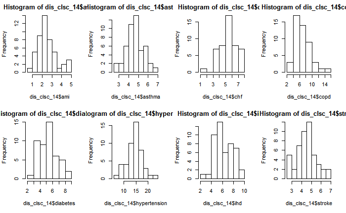

```r
#summary.data.frame(dis_clsc_14);dim(dis_clsc_14) # to check whether data are normally-distributed
#plot(dis_clsc_14)
par(mfrow= c(2,4))
hist(dis_clsc_14$ami); hist(dis_clsc_14$asthma);hist(dis_clsc_14$chf); hist(dis_clsc_14$copd)
hist(dis_clsc_14$diabetes); hist(dis_clsc_14$hypertension);hist(dis_clsc_14$ihd); hist(dis_clsc_14$stroke)
```

```r
dis.clsc.bn=iamb(dis_clsc_14, debug = FALSE)  # constrain-based learning
dis.clsc.bn2=hc(dis_clsc_14, debug = FALSE)   # score-based learning
all.equal(dis.clsc.bn, dis.clsc.bn2)
```

```
[1] "Different number of directed/undirected arcs"
```

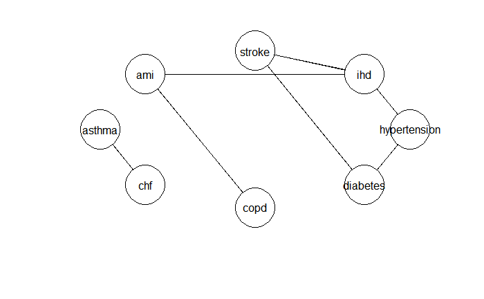

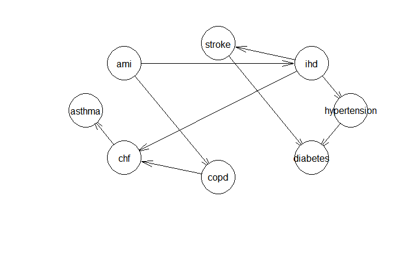

```r
par(mfrow= c(1,1))
plot(dis.clsc.bn); plot(dis.clsc.bn2)
```

```r
arc.strength(dis.clsc.bn2, dis_clsc_14, debug = TRUE)
```

```
----------------------------------------------------------------

  Bayesian network learned via Score-based methods

  model:
   [ami][copd|ami][ihd|ami][chf|copd:ihd][hypertension|ihd][stroke|ihd][asthma|chf][diabetes|hypertension:stroke]
  nodes:                                 8
  arcs:                                  9
    undirected arcs:                     0
    directed arcs:                       9
  average markov blanket size:           2.75
  average neighbourhood size:            2.25
  average branching factor:              1.12

  learning algorithm:                    Hill-Climbing
  score:                                 BIC (Gauss.)
  penalization coefficient:              1.935601
  tests used in the learning procedure:  91
  optimized:                             TRUE

* current score: -608.7871
----------------------------------------------------------------
* original scores of the nodes of the graphs are:
  > original score for node ami is -66.8297 .
  > original score for node asthma is -62.49245 .
  > original score for node chf is -78.99173 .
  > original score for node copd is -102.2566 .
  > original score for node diabetes is -71.90614 .
  > original score for node hypertension is -110.7236 .
  > original score for node ihd is -65.50419 .
  > original score for node stroke is -50.08276 .
----------------------------------------------------------------
* computing strength for arc ami -> ihd .
  > updated score for node ihd is -91.58374 .
  > score delta -26.07956 .
----------------------------------------------------------------
* computing strength for arc ihd -> stroke .
  > updated score for node stroke is -69.48063 .
  > score delta -19.39787 .
----------------------------------------------------------------
```

[output cut: 12 more lines]

```
* computing strength for arc ihd -> chf .
  > updated score for node chf is -85.32585 .
  > score delta -6.334117 .
----------------------------------------------------------------
* computing strength for arc copd -> chf .
  > updated score for node chf is -81.05962 .
  > score delta -2.067887 .
----------------------------------------------------------------
* computing strength for arc stroke -> diabetes .
  > updated score for node diabetes is -73.76597 .
  > score delta -1.859837 .
----------------------------------------------------------------
* computing strength for arc chf -> asthma .
  > updated score for node asthma is -63.8962 .
  > score delta -1.403749 .
```

|  | from | to | strength |
| --- | --- | --- | --- |
| 1 | ami | ihd | -26.079555 |
| 2 | ihd | stroke | -19.397872 |
| 3 | ihd | hypertension | -14.555775 |
| 4 | hypertension | diabetes | -3.203815 |
| 5 | ami | copd | -8.642319 |
| 6 | ihd | chf | -6.334117 |
| 7 | copd | chf | -2.067887 |
| 8 | stroke | diabetes | -1.859837 |
| 9 | chf | asthma | -1.403749 |

The **strength** is measured by the score gain/loss which would be caused by the arc’s removal. In other words, it is the difference between the score of the network including the arc and the score of the network in which the arc is not present. Negative values correspond to decreases in the network score and positive values correspond to increases in the network score (the stronger the relationship, the more negative the difference)

### Dataset-2

```r
setwd("C:/Users/myuan/Google Drive/1. Practicum/3. Notes/9. BN/3. Pophr")
```

```
The working directory was changed to C:/Users/myuan/Google Drive/1. Practicum/3. Notes/9. BN/3. Pophr inside a notebook chunk. The working directory will be reset when the chunk is finished running. Use the knitr root.dir option in the setup chunk to change the working directory for notebook chunks.
```

```r
dis.indiv<-read.table(file = 'Disease_individual level_bn/SELECT___from_discohort14.tsv', sep = '\t', header = TRUE)
names(dis.indiv)<- c("year", "id", "diabetes", "ami","amputation","asthma","chf","copd", "epilepsy",
                     "hiv", "ht", "hypertension", "ihd", "stroke")
summary(is.na(dis.indiv$year)) ;summary(is.na(dis.indiv$id))
```

```
   Mode   FALSE
logical 1000428
   Mode   FALSE
logical 1000428
```

```r
# the 0, 1 will be treated as continous variables if don't factorize it
dis.indiv.cp<-dis.indiv
for (i in 3:ncol(dis.indiv.cp)) {
    dis.indiv.cp[,i]<-ifelse(is.na(dis.indiv.cp[,i]), 0, 1)
}
dis.indiv.cp<-dis.indiv.cp[,colnames(dis.indiv.cp) %in% c("ami", "asthma", "chf", "copd","diabetes", "hypertension", "ihd","stroke")]
# create 0, 1 as factor varaibles
dis_indiv_14<- dis.indiv.cp
for (i in 1:ncol(dis_indiv_14)) {
    dis_indiv_14[,i] <- factor(dis_indiv_14[,i])
}
levels(dis_indiv_14$stroke)
```

```
[1] "0" "1"
```

```r
rm(dis.indiv); rm(dis.indiv.cp)
```

```r
indiv.bn=iamb(dis_indiv_14)
indiv.bn2=hc(dis_indiv_14)
all.equal(indiv.bn, indiv.bn2)
```

```
[1] "Different number of directed/undirected arcs"
```

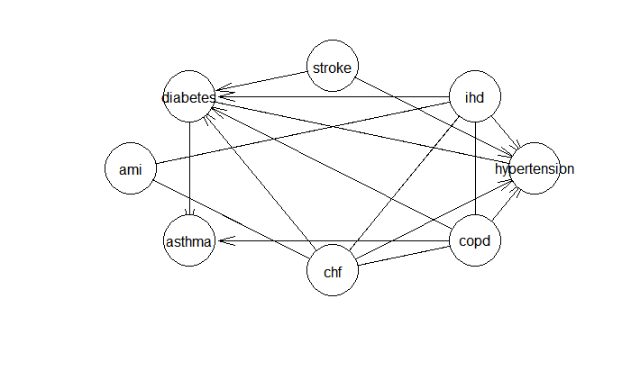

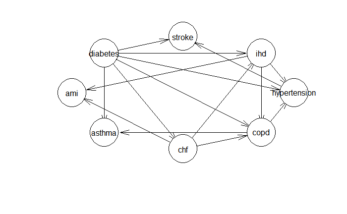

```r
par(mfrow= c(1,1))
plot(indiv.bn);plot(indiv.bn2)
```

```r
arc.strength(indiv.bn2, dis_indiv_14)
```

|  | from | to | strength |
| --- | --- | --- | --- |
| 1 | diabetes | hypertension | -8740.4711294 |
| 2 | diabetes | ihd | -4352.3283649 |
| 3 | diabetes | copd | -2086.0859961 |
| 4 | diabetes | asthma | -1800.2226319 |
| 5 | ihd | ami | -1642.5691025 |
| 6 | diabetes | chf | -1822.5914247 |
| 7 | diabetes | stroke | -274.9767827 |
| 8 | chf | ihd | -265.3897219 |
| 9 | ihd | hypertension | -150.2508072 |
| 10 | ihd | copd | -33.4546424 |

[output cut: 5 more lines]

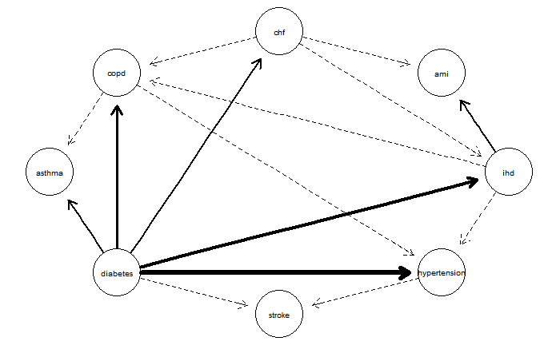

```r
strength.indiv = arc.strength(indiv.bn2, dis_indiv_14)
strength.plot(indiv.bn2, strength.indiv, threshold = -1500, layout= "circo" )
```

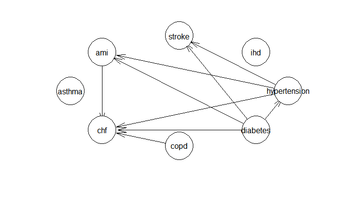

```r
plot(pophr_cg)  # plot the causal graph in PopHR
```

### add known relationships as the prior information to the structure learning

```r
# we know that ihd and ami are not causal related but they are easily misdiagnosed from each other, therefore,
# add ami <->ihd to the blacklist to BNs constructed from dataset-1
blacklist= data.frame(from=c( "ami", "ihd"), to =c( "ihd", "ami"))
dis.clsc.bn2.modf= hc(dis_clsc_14, blacklist = blacklist)
plot(dis.clsc.bn2.modf)
plot(dis.clsc.bn2)
arc.strength(dis.clsc.bn2, dis_clsc_14)
```

[output not shown]

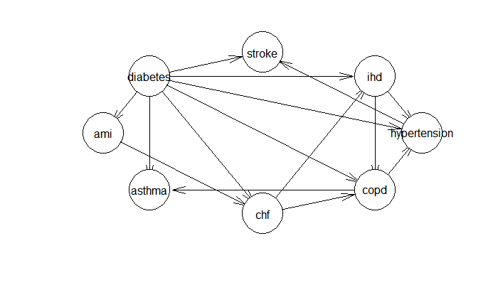

```r
# add ami <->ihd to the blacklist to BNs constructed from dataset-3
indiv.bn2.modf=hc(dis_indiv_14, blacklist = blacklist)
plot(indiv.bn2.modf)
```

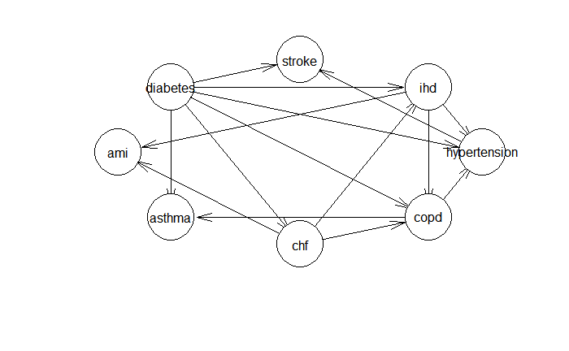

```r
plot(indiv.bn2)
```

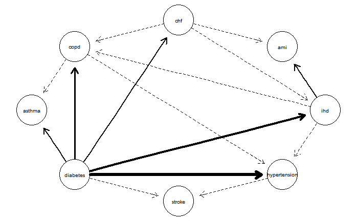

```r
strength.plot(indiv.bn2, strength.indiv, threshold = -500, layout= "circo" )
```

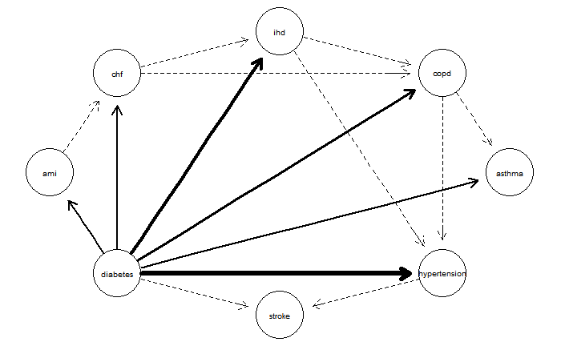

```r
strength.indiv.modf = arc.strength(indiv.bn2.modf, dis_indiv_14)
strength.plot(indiv.bn2.modf, strength.indiv.modf, threshold = -500, layout= "circo" )
```